# MSc-ESC

## SECTION 5 - Model Evaluation OVERVIEW

This section evaluates the fit of the model’s using the car package MLR requires the residuals to be ~ IID N(0, sigma^2) the residuals will be standardized for the assessment Normality Assumptions will be accessed using: i. Normality tests from the nortest package ii. Visualizations such as histograms, QQ-plots, Residual Plots and Add Variable Plots Constant Variance will be accessed using: i. non-constant variance test Multi-collinearity will be accessed using: i. variance inflation factors Outliers will be accessed using: i. Cooks Distance

```r
# load relevant libraries
library(rmarkdown)
library(knitr)
library(car)
library(MASS)
library(nortest)
library(lmtest)
library(dplyr)
```

```r
#-- Data --#

# load in the historic voting data for deriving the voting blocs
processed_data <- read.csv(file = "./data/processed_data.csv", header = T)
# split the televote data
televote_data <- processed_data %>% filter(Voting_Method_J == 0)
# split out the jury vote data
jury_data <- processed_data %>% filter(Voting_Method_J == 1)
```

## Overall Model

```r
# load final overall model
my_model_overall <- readRDS("./models/overall_final_model.RDS")
# extract out the model coefficients
overall_model_coeff <- names(my_model_overall$coefficients)[-1]
# recreate the model formula
overall_final_model_form<- as.formula(paste('Points ~', paste(overall_model_coeff, collapse = ' + ')))
# generate model summary
summary(my_model_overall)
```

```
##
## Call:
## lm(formula = overall_final_model_form, data = processed_data)
##
## Residuals:
##     Min      1Q  Median      3Q     Max
## -9.5505 -2.3301 -0.2858  2.1846  7.8517
##
## Coefficients:
##                  Estimate Std. Error t value Pr(>|t|)
## (Intercept)        3.7244     0.6169   6.037 2.64e-09 ***
## Average_Points     0.4798     0.1253   3.830 0.000141 ***
## acousticness       0.6959     0.1302   5.344 1.26e-07 ***
## speechiness        0.6973     0.1362   5.119 4.05e-07 ***
## METRIC_Citizens    0.3251     0.1399   2.324 0.020438 *
## TC_PerfType_Solo   1.4412     0.5613   2.568 0.010457 *
## key_0              1.2923     0.4516   2.861 0.004353 **
## CAP_DIST_km        0.2956     0.1280   2.309 0.021260 *
## OOA                1.2837     0.4512   2.845 0.004579 **
## FC_NonCOB          0.3604     0.1391   2.592 0.009766 **
## ComSONGLAN         0.2760     0.1287   2.145 0.032338 *
## ---
## Signif. codes:  0 '***' 0.001 '**' 0.01 '*' 0.05 '.' 0.1 ' ' 1
##
## Residual standard error: 3.074 on 647 degrees of freedom
## Multiple R-squared:  0.1762, Adjusted R-squared:  0.1635
## F-statistic: 13.84 on 10 and 647 DF,  p-value: < 2.2e-16
```

## Transformation of Response Variable

```r
# Apply box-cox transformation on the model to improve the normality assumptions
# box-cox transformation using car
bct <- MASS::boxcox(object = my_model_overall)
```

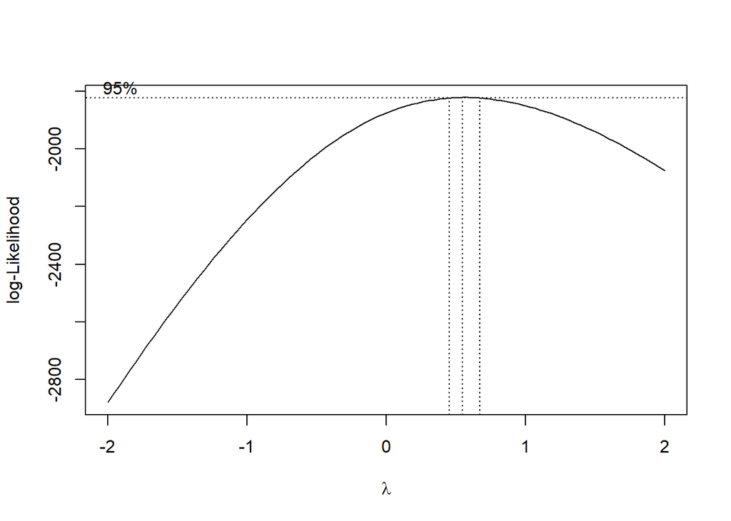

```r
# find optimal box-cox power transformation power
p <- bct$x[which.max(x = bct$y)]
# transform points using the optimal power transformation
bctPoints <- (((processed_data$Points)^p) - 1)/(p)
# recreate the model formula
overall_final_model_bct_form<- as.formula(paste('bctPoints ~', paste(overall_model_coeff, collapse = ' + ')))
# refit final model with with box-cox power transformation
my_model_overall <- lm(formula = overall_final_model_bct_form, data = processed_data)
# generate model summary
summary(my_model_overall)
```

```
##
## Call:
## lm(formula = overall_final_model_bct_form, data = processed_data)
##
## Residuals:
##     Min      1Q  Median      3Q     Max
## -4.7417 -1.0276  0.0449  1.1112  3.3083
##
## Coefficients:
##                  Estimate Std. Error t value Pr(>|t|)
## (Intercept)       1.71220    0.29239   5.856 7.55e-09 ***
## Average_Points    0.20209    0.05938   3.403 0.000706 ***
## acousticness      0.34061    0.06173   5.518 4.96e-08 ***
## speechiness       0.33666    0.06456   5.215 2.48e-07 ***
## METRIC_Citizens   0.12269    0.06630   1.851 0.064672 .
## TC_PerfType_Solo  0.69660    0.26601   2.619 0.009035 **
## key_0             0.65422    0.21405   3.056 0.002332 **
## CAP_DIST_km       0.12426    0.06069   2.048 0.041007 *
## OOA               0.62781    0.21385   2.936 0.003446 **
## FC_NonCOB         0.18387    0.06591   2.790 0.005428 **
## ComSONGLAN        0.14046    0.06099   2.303 0.021585 *
## ---
## Signif. codes:  0 '***' 0.001 '**' 0.01 '*' 0.05 '.' 0.1 ' ' 1
##
## Residual standard error: 1.457 on 647 degrees of freedom
## Multiple R-squared:  0.169,  Adjusted R-squared:  0.1562
## F-statistic: 13.16 on 10 and 647 DF,  p-value: < 2.2e-16
```

## Evaluate the Fit of the Model

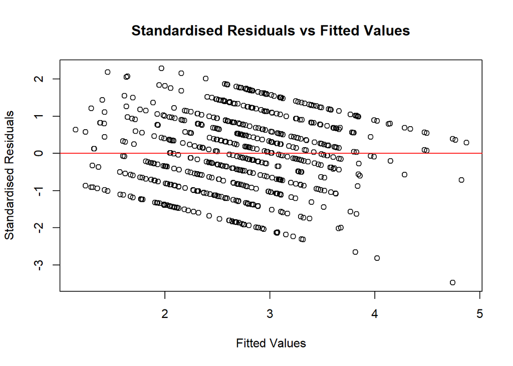

```r
# create standardize residuals
sresid <- studres(my_model_overall)
# Residual vs fits plot
plot(x = my_model_overall$fitted.values, y = sresid, main = "Standardised Residuals vs Fitted Values", xlab = "Fitted Values", ylab = "Standardised Residuals")
# add red horizontal line through y-axis 0
abline(h = 0, col = "red")
```

```r
# Assessing Outliers
# Bonferonni p-value for most extreme obs
outlierTest(my_model_overall)
```

```
## No Studentized residuals with Bonferroni p < 0.05
## Largest |rstudent|:
##      rstudent unadjusted p-value Bonferroni p
## 487 -3.473914         0.00054721      0.36006
```

```r
# final outlier residuals
which(sresid < -2)
```

```
##  39  77 103 177 241 360 464 487 516 529 531 535 536 618
##  39  77 103 177 241 360 464 487 516 529 531 535 536 618
```

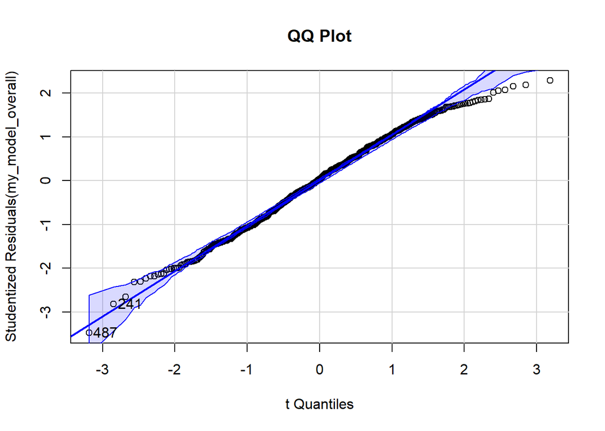

```
## [1] 241 487
```

```r
# qq-plot for studentized residuals
qqPlot(my_model_overall, main = "QQ Plot")
```

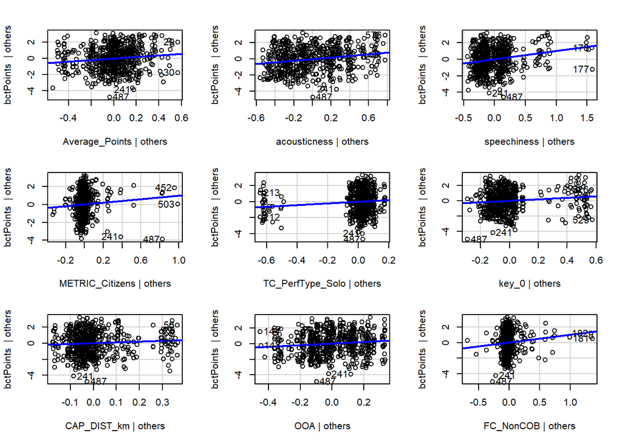

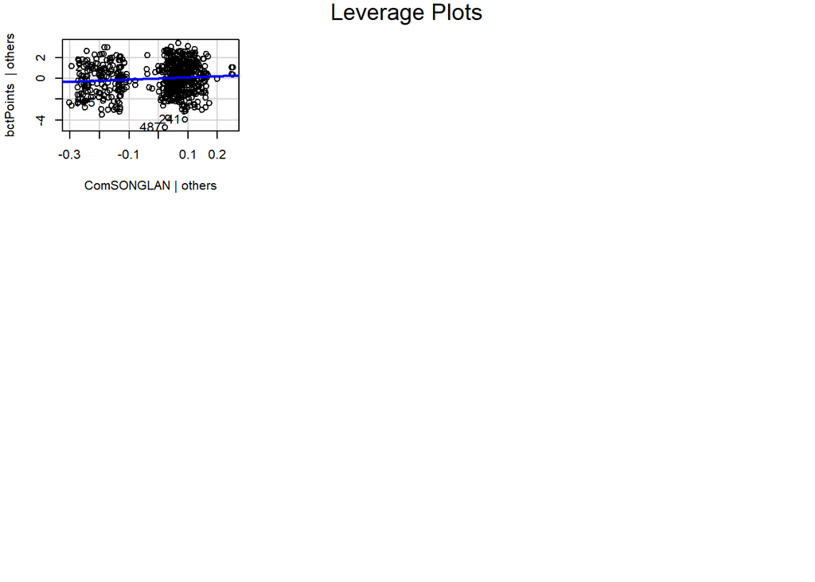

```r
# leverage plots
leveragePlots(my_model_overall)
```

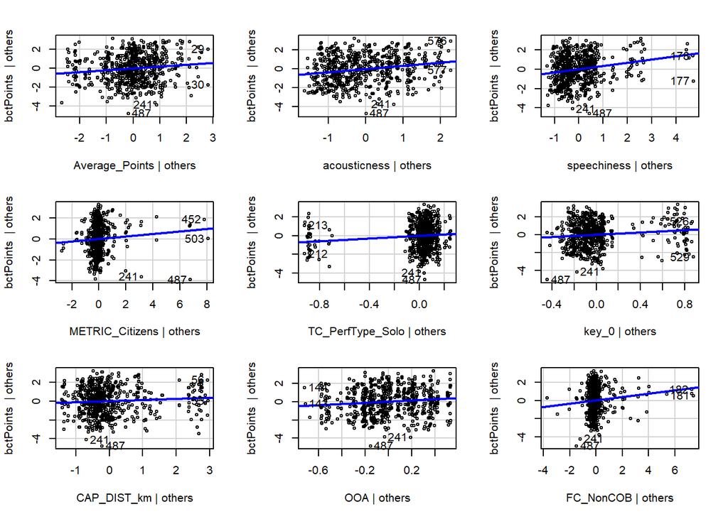

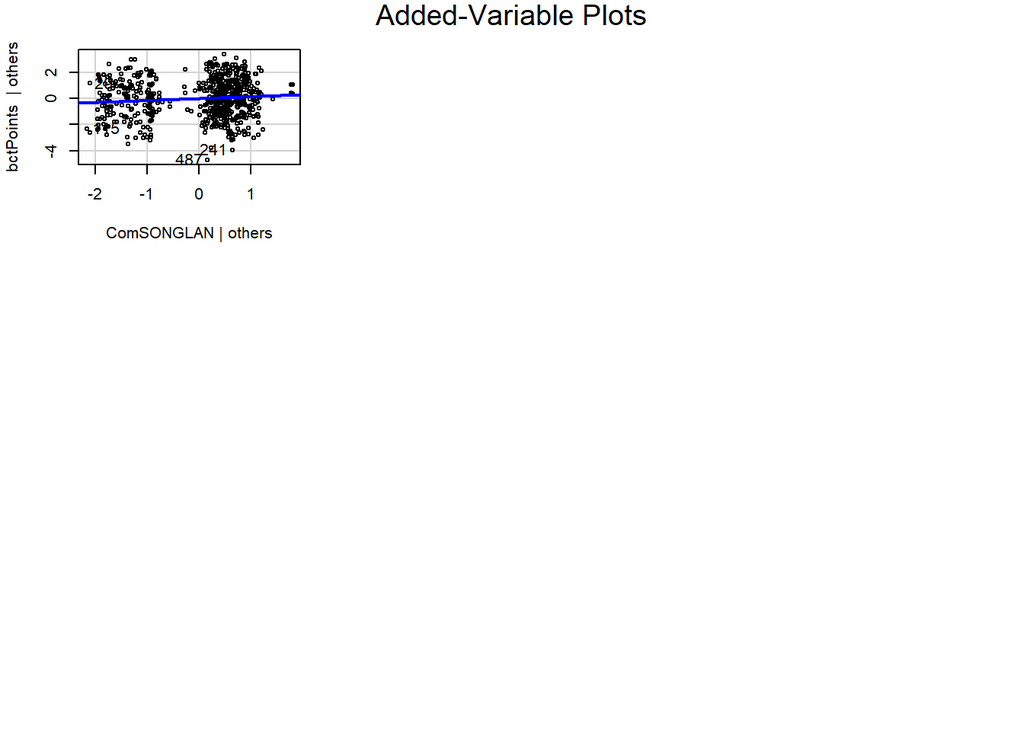

```r
# Added variable Plots
avPlots(my_model_overall)
```

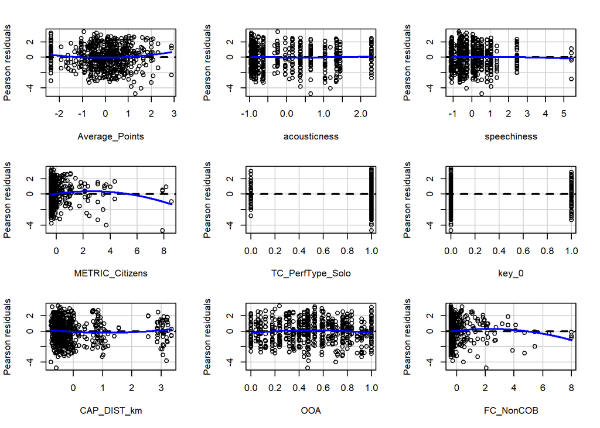

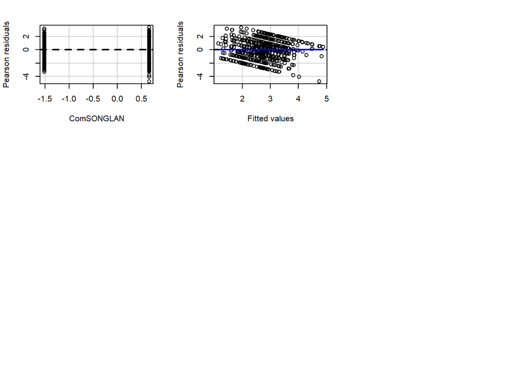

```
##                  Test stat Pr(>|Test stat|)
## Average_Points      2.2247         0.026443 *
## acousticness        0.5338         0.593682
## speechiness        -0.4246         0.671259
## METRIC_Citizens    -2.7460         0.006201 **
## TC_PerfType_Solo    0.7835         0.433605
## key_0               0.5665         0.571238
## CAP_DIST_km         1.8086         0.070981 .
## OOA                -2.4388         0.015004 *
## FC_NonCOB          -2.2184         0.026874 *
## ComSONGLAN          1.2837         0.199719
## Tukey test         -0.0599         0.952216
## ---
## Signif. codes:  0 '***' 0.001 '**' 0.01 '*' 0.05 '.' 0.1 ' ' 1
```

```r
# Residual Plots
residualPlots(my_model_overall)
```

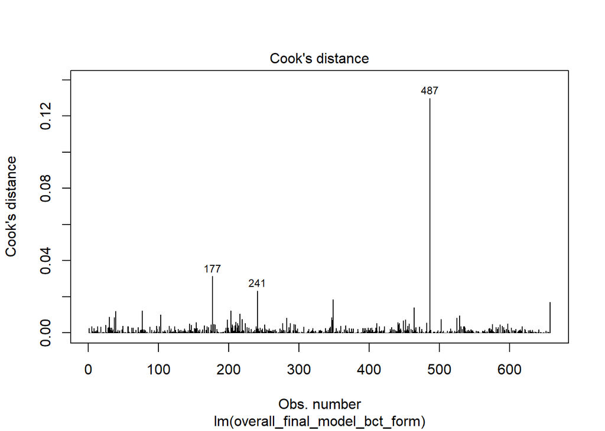

```r
# Cook's D plot
# identify D values > 4/(n-k-1)
cutoff <- 4/((nrow(processed_data)-length(my_model_overall$coefficients)-2))
# Crooks Distance plot
plot(my_model_overall, which = 4, cook.levels = cutoff)
```

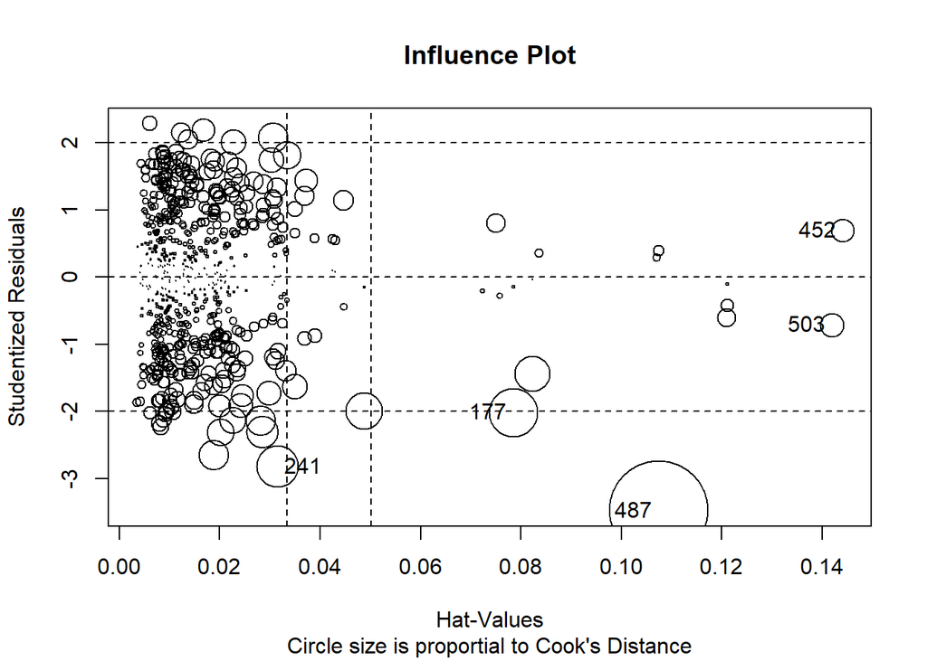

|  | StudRes | Hat | CookD |
| --- | --- | --- | --- |
| 177 | -2.0146453 | 0.0784447 | 0.0312607 |
| 241 | -2.8196641 | 0.0314946 | 0.0232539 |
| 452 | 0.6934167 | 0.1440912 | 0.0073647 |
| 487 | -3.4739137 | 0.1074300 | 0.1298262 |
| 503 | -0.7100016 | 0.1418771 | 0.0075827 |

```r
# Influence Plot
influencePlot(my_model_overall, id.method = "identify", main = "Influence Plot", sub = "Circle size is proportial to Cook's Distance" )
```

Normality Test Ho: The data is normally distributed Ha: the data is not normally distributed

```r
# Normality Test
shapiro.test(sresid)
```

```
##
##  Shapiro-Wilk normality test
##
## data:  sresid
## W = 0.99127, p-value = 0.0006293
```

```r
ad.test(sresid)
```

```
##
##  Anderson-Darling normality test
##
## data:  sresid
## A = 1.173, p-value = 0.004584
```

```r
cvm.test(sresid)
```

```
##
##  Cramer-von Mises normality test
##
## data:  sresid
## W = 0.16383, p-value = 0.01564
```

```r
lillie.test(sresid)
```

```
##
##  Lilliefors (Kolmogorov-Smirnov) normality test
##
## data:  sresid
## D = 0.032825, p-value = 0.08898
```

```r
pearson.test(sresid)
```

```
##
##  Pearson chi-square normality test
##
## data:  sresid
## P = 37.024, p-value = 0.04352
```

```r
sf.test(sresid)
```

```
##
##  Shapiro-Francia normality test
##
## data:  sresid
## W = 0.99178, p-value = 0.001487
```

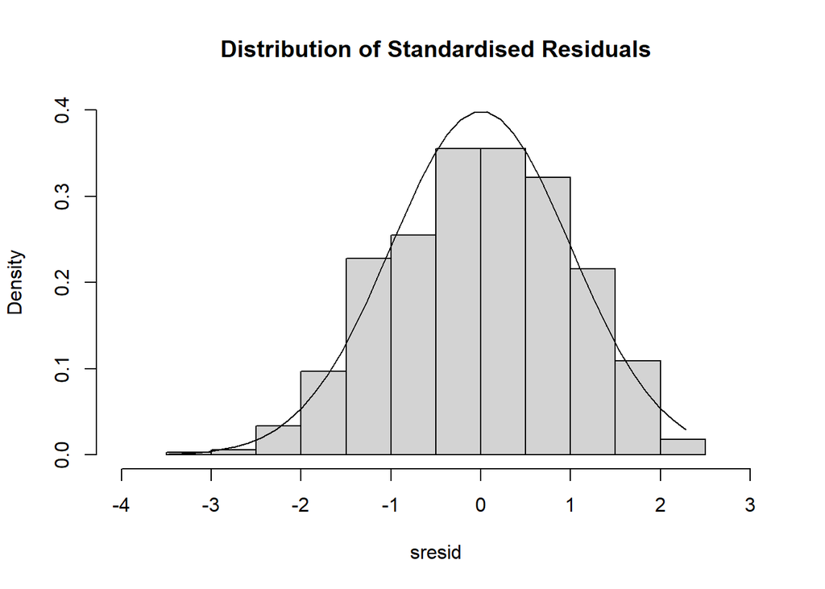

```r
# the data is not normally distributed
# Histogram of residuals
hist(sresid, freq = FALSE, main = "Distribution of Standardised Residuals", ylim = c(0,0.4),  xlim = c(-4, 3))
xfit <- seq(min(sresid, na.rm = TRUE), max(sresid, na.rm = TRUE), length = 40)
yfit <- dnorm(xfit)
lines(xfit, yfit)
```

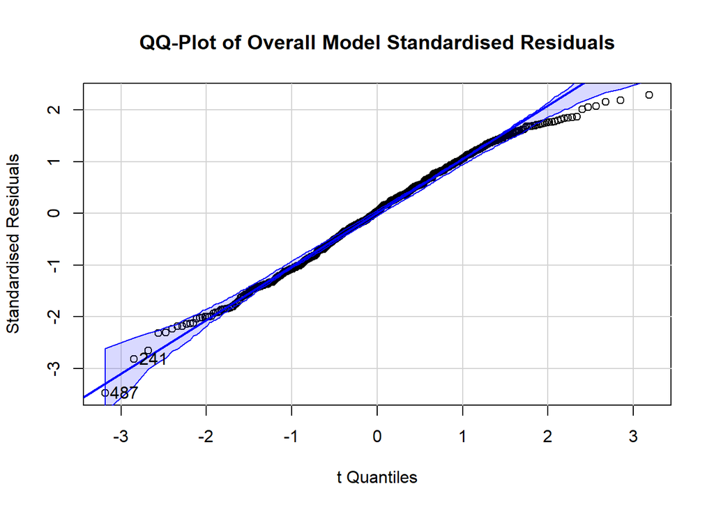

```
## [1] 241 487
```

```r
# QQ-plot of the data
qqPlot(my_model_overall, ylab = "Standardised Residuals", main = "QQ-Plot of Overall Model Standardised Residuals")
```

Non-Constant Error Variance Test Ho: constant error variance Ha: Non-constant error Variance

```r
# Non-Constant Error Variance Test
ncvTest(my_model_overall)
```

```
## Non-constant Variance Score Test
## Variance formula: ~ fitted.values
## Chisquare = 0.03663296, Df = 1, p = 0.84821
```

```r
bptest(my_model_overall)
```

```
##
##  studentized Breusch-Pagan test
##
## data:  my_model_overall
## BP = 12.715, df = 10, p-value = 0.2401
```

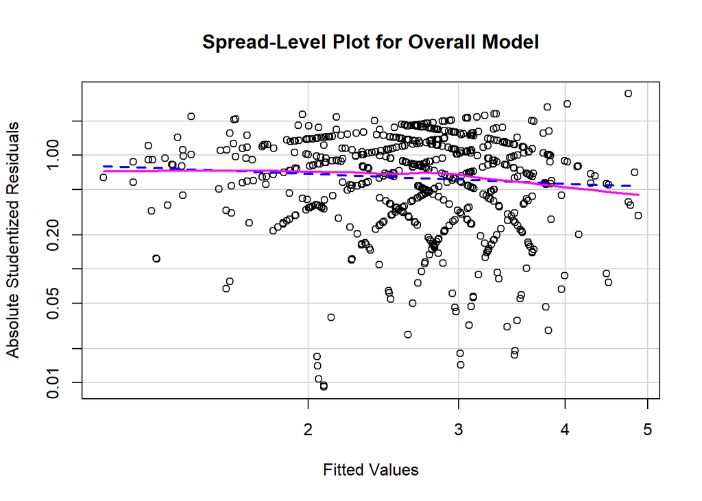

```
##
## Suggested power transformation:  1.282955
```

```r
# plot studentized residuals vs. fitted values
spreadLevelPlot(my_model_overall, main = "Spread-Level Plot for Overall Model")
```

```r
# Variance Inflation Factors
vif(my_model_overall)
```

```
##   Average_Points     acousticness      speechiness  METRIC_Citizens
##         1.091139         1.179141         1.289927         1.360161
## TC_PerfType_Solo            key_0      CAP_DIST_km              OOA
##         1.104542         1.246838         1.139690         1.188927
##        FC_NonCOB       ComSONGLAN
##         1.344230         1.150996
```

```r
sqrt(vif(my_model_overall)) > 2
```

```
##   Average_Points     acousticness      speechiness  METRIC_Citizens
##            FALSE            FALSE            FALSE            FALSE
## TC_PerfType_Solo            key_0      CAP_DIST_km              OOA
##            FALSE            FALSE            FALSE            FALSE
##        FC_NonCOB       ComSONGLAN
##            FALSE            FALSE
```

```r
# No signs of collinearity
```

## TELEVOTE MODEL

```r
# load final televote model
my_model_tele <- readRDS("./models/televote_final_model.RDS")
# extract out the model coefficients
tele_model_coeff <- names(my_model_tele$coefficients)[-1]
# recreate the model formula
televote_final_model_form<- as.formula(paste('Points ~', paste(tele_model_coeff, collapse = ' + ')))
# generate model summary
summary(my_model_tele)
```

```
##
## Call:
## lm(formula = televote_final_model_form, data = televote_data)
##
## Residuals:
##     Min      1Q  Median      3Q     Max
## -7.3561 -1.9688 -0.0461  1.7443  6.7011
##
## Coefficients:
##                 Estimate Std. Error t value Pr(>|t|)
## (Intercept)       5.1314     0.3466  14.806  < 2e-16 ***
## METRIC_Citizens   0.5344     0.1555   3.436 0.000668 ***
## Average_Points    0.8126     0.1607   5.057 7.22e-07 ***
## TC_NumNeigh       0.7464     0.1742   4.286 2.42e-05 ***
## speechiness       0.5175     0.1656   3.125 0.001943 **
## acousticness      0.4804     0.1681   2.858 0.004550 **
## FC_NonCitzens     0.6452     0.1767   3.652 0.000304 ***
## VBlocs1_TC_13    -6.8165     2.1841  -3.121 0.001968 **
## OOA               0.8913     0.6028   1.479 0.140203
## CAP_DIST_km       0.3029     0.1726   1.755 0.080254 .
## ---
## Signif. codes:  0 '***' 0.001 '**' 0.01 '*' 0.05 '.' 0.1 ' ' 1
##
## Residual standard error: 2.772 on 317 degrees of freedom
## Multiple R-squared:  0.3384, Adjusted R-squared:  0.3196
## F-statistic: 18.02 on 9 and 317 DF,  p-value: < 2.2e-16
```

## Transformation of Response Variable

```r
# Apply box-cox transformation on the model to improve the normality assumptions
# box-cox transformation using car
bct <- boxCox(object = my_model_tele)
```

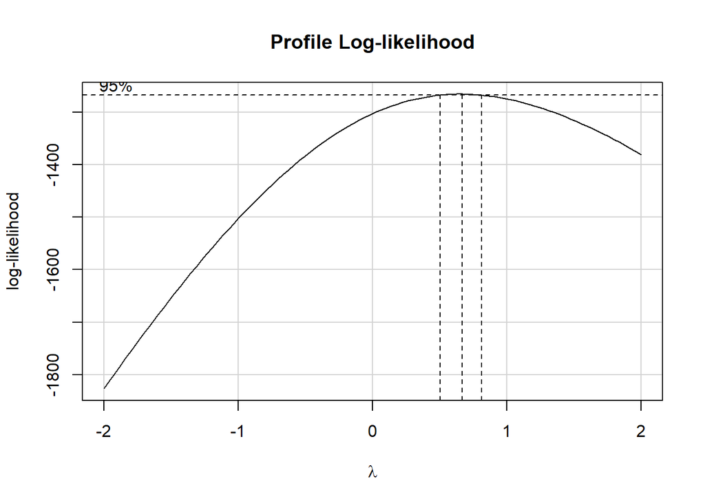

```r
# find optimal box-cox power transformation power
p <- bct$x[which.max(x = bct$y)]
# transform points using the optimal power transformation
bctPoints <- (((televote_data$Points)^p) - 1)/(p)
# recreate the model formula
televote_final_model_bct_form <- as.formula(paste('bctPoints ~', paste(tele_model_coeff, collapse = ' + ')))
# refit final model with with box-cox power transformation
my_model_tele <- lm(formula = televote_final_model_bct_form, data = televote_data)
# generate model summary
summary(my_model_tele)
```

```
##
## Call:
## lm(formula = televote_final_model_bct_form, data = televote_data)
##
## Residuals:
##     Min      1Q  Median      3Q     Max
## -4.6127 -1.0874  0.0907  1.1155  3.5345
##
## Coefficients:
##                 Estimate Std. Error t value Pr(>|t|)
## (Intercept)      2.75365    0.20088  13.708  < 2e-16 ***
## METRIC_Citizens  0.28085    0.09013   3.116 0.002000 **
## Average_Points   0.44003    0.09313   4.725 3.47e-06 ***
## TC_NumNeigh      0.44883    0.10095   4.446 1.21e-05 ***
## speechiness      0.30365    0.09599   3.163 0.001711 **
## acousticness     0.28053    0.09743   2.879 0.004257 **
## FC_NonCitzens    0.35982    0.10241   3.514 0.000506 ***
## VBlocs1_TC_13   -3.80137    1.26592  -3.003 0.002888 **
## OOA              0.52110    0.34938   1.492 0.136818
## CAP_DIST_km      0.19110    0.10006   1.910 0.057054 .
## ---
## Signif. codes:  0 '***' 0.001 '**' 0.01 '*' 0.05 '.' 0.1 ' ' 1
##
## Residual standard error: 1.607 on 317 degrees of freedom
## Multiple R-squared:  0.3246, Adjusted R-squared:  0.3054
## F-statistic: 16.92 on 9 and 317 DF,  p-value: < 2.2e-16
```

## Evaluate the Fit of the Model

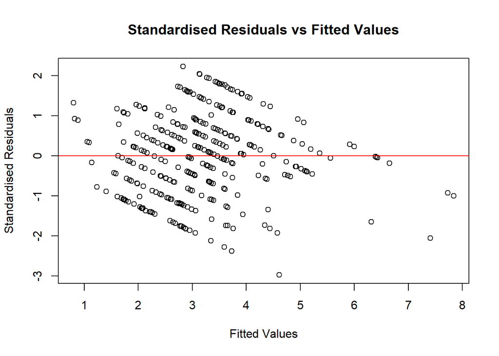

```r
# create standardize residuals
sresid <- studres(my_model_tele)
# Residual vs fits plot
plot(x = my_model_tele$fitted.values, y = sresid, main = "Standardised Residuals vs Fitted Values", xlab = "Fitted Values", ylab = "Standardised Residuals")
# add red horizontal line through y-axis 0
abline(h = 0, col = "red")
```

```r
# Assessing Outliers
# Bonferonni p-value for most extreme obs
outlierTest(my_model_tele)
```

```
## No Studentized residuals with Bonferroni p < 0.05
## Largest |rstudent|:
##     rstudent unadjusted p-value Bonferroni p
## 56 -2.970711          0.0031989           NA
```

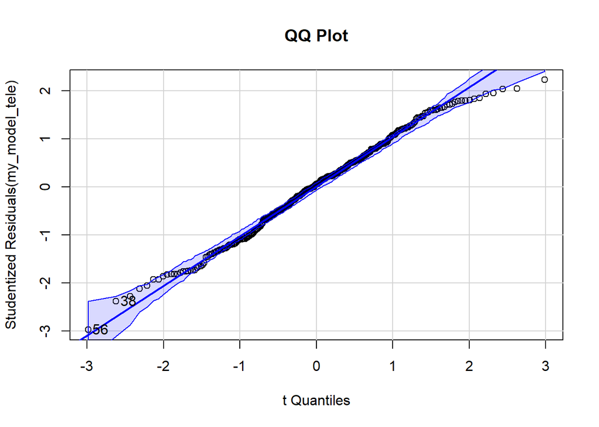

```
## [1] 38 56
```

```r
#qq plot for studentized residuals
qqPlot(my_model_tele, main = "QQ Plot")
```

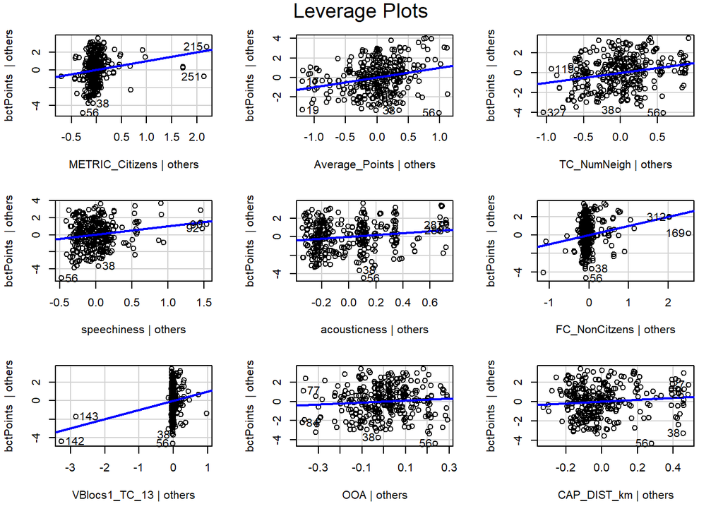

```r
# leverage plots
leveragePlots(my_model_tele)
```

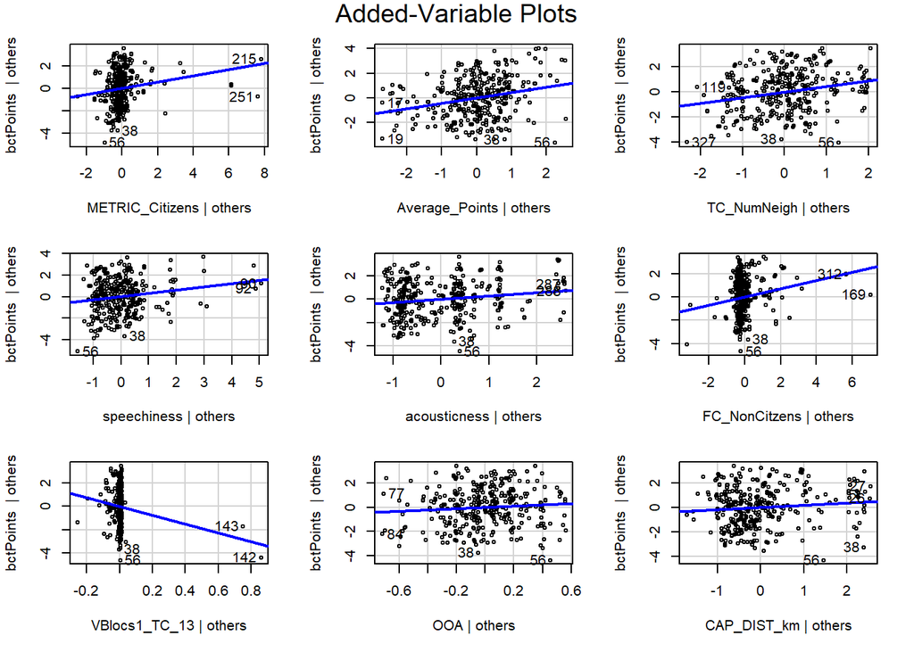

```r
# Added variable Plots
avPlots(my_model_tele)
```

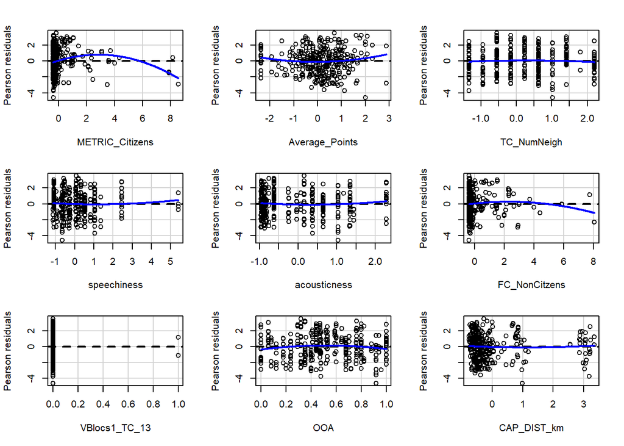

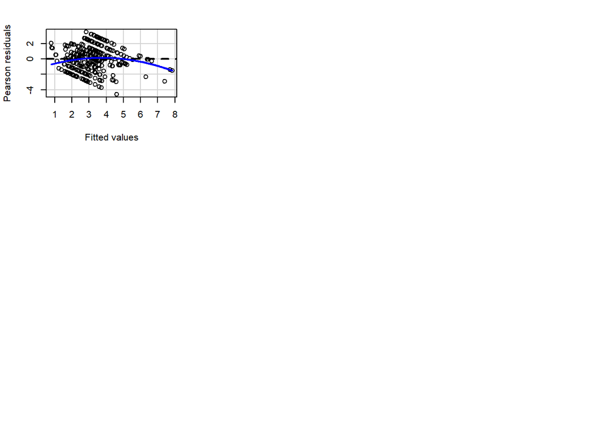

```
##                 Test stat Pr(>|Test stat|)
## METRIC_Citizens   -4.2900        2.378e-05 ***
## Average_Points     1.8891         0.059792 .
## TC_NumNeigh       -0.7737         0.439702
## speechiness        0.8468         0.397722
## acousticness       1.3501         0.177938
## FC_NonCitzens     -1.5501         0.122130
## VBlocs1_TC_13      0.8875         0.375504
## OOA               -1.9812         0.048437 *
## CAP_DIST_km        0.5182         0.604654
## Tukey test        -3.2247         0.001261 **
## ---
## Signif. codes:  0 '***' 0.001 '**' 0.01 '*' 0.05 '.' 0.1 ' ' 1
```

```r
# Residual Plots
residualPlots(my_model_tele)
```

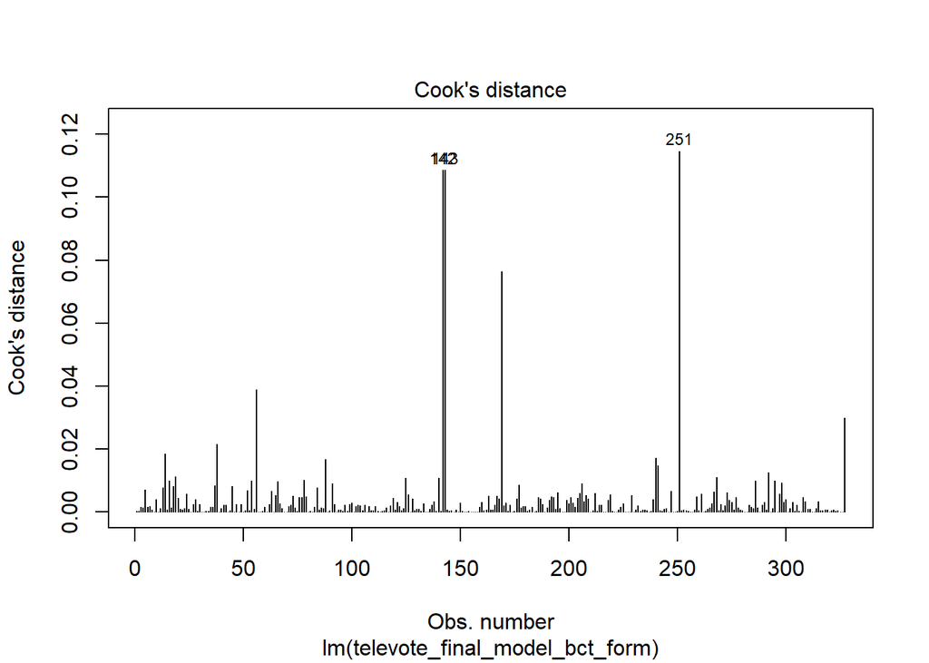

```r
# Cook's D plot
# identify D values > 4/(n-k-1)
cutoff <- 4/((nrow(processed_data) - length(my_model_tele$coefficients) - 2))
# Crooks Distance plot
plot(my_model_tele, which = 4, cook.levels = cutoff)
```

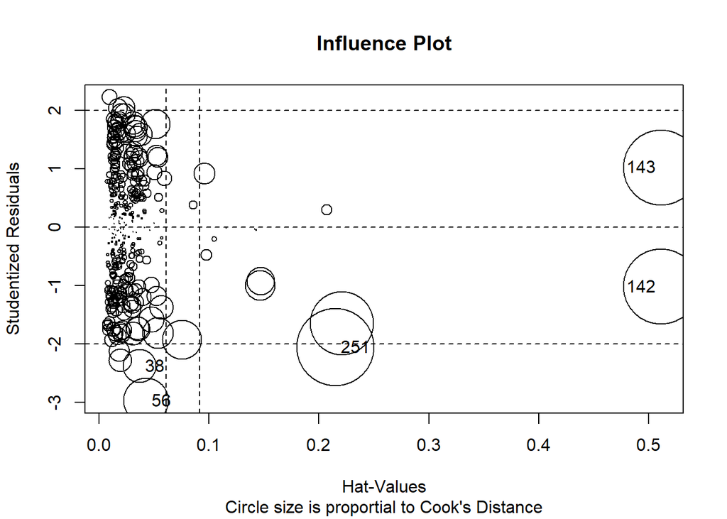

|  | StudRes | Hat | CookD |
| --- | --- | --- | --- |
| 38 | -2.381778 | 0.0370859 | 0.0215312 |
| 56 | -2.970711 | 0.0431574 | 0.0388459 |
| 142 | -1.018872 | 0.5111820 | 0.1085464 |
| 143 | 1.018872 | 0.5111820 | 0.1085464 |
| 251 | -2.055209 | 0.2151787 | 0.1146427 |

```r
# Influence Plot
influencePlot(my_model_tele, id.method = "identify", main = "Influence Plot", sub = "Circle size is proportial to Cook's Distance" )
```

Normality Test Ho: The data is normally distributed Ha: the data is not normally distributed

```r
# Normality Test
shapiro.test(sresid)
```

```
##
##  Shapiro-Wilk normality test
##
## data:  sresid
## W = 0.99075, p-value = 0.03758
```